# ¿Quiénes protestan? - Trabajo Maestría

# Preparando la data

```r
rm(list = ls()) # limpiar el working environment

linkADrive='https://docs.google.com/spreadsheets/d/e/2PACX-1vQoN_1tfvAClKCO6wjHLy7rGNdbZx2nuvTm99d2FzrwIoohr2rqetFfCLTErgYYTg/pub?gid=486140846&single=true&output=csv'

protestas=read.csv(linkADrive)

head(protestas)
```

```
##       NOM_DIST NOM_PROV UBIGEO CONFLICTOS PP_Nac_Loc PP_Nom POBLACION ALTITUD
## 1      ACOMAYO  ACOMAYO  80201          0          1     SP      4523    3235
## 2       ACOPIA  ACOMAYO  80202          0          2   MRIP      3121    3724
## 3         ACOS  ACOMAYO  80203          0          1     SP      2328    3106
## 4 MOSOC LLACTA  ACOMAYO  80204          0          1     SP       983    3820
## 5   POMACANCHI  ACOMAYO  80205          0          2    APP      7515    3709
## 6     RONDOCAN  ACOMAYO  80206          1          1     SP      1800    3394
##   TRANS_RENTA TRANS_REG TRANS_TOTAL TRANS_TOTAL_MILL EJE_RENTA EJE_REG
## 1     2114571   2963236     5077807             5.08   2691165 3776274
## 2     1443050   2026153     3469203             3.47   1941071 2433242
## 3     1030209   1444492     2474700             2.47   1019208 1339532
## 4     1008992   1409493     2418484             2.42   1278084 1522283
## 5     3479483   4878068     8357551             8.36   3191264 5427173
## 6      703160    983352     1686511             1.69    774629 1002276
##   EJE_TOTAL EJE_TOTAL_MILL      PIM POR_EJE_RELA RENTA_PER
## 1   6467439           6.47  8342582        77.52    467.52
## 2   4374313           4.37  6583168        66.45    462.37
## 3   2358740           2.36  3282897        71.85    442.53
## 4   2800367           2.80  4205056        66.60   1026.44
## 5   8618437           8.62 11357031        75.89    463.01
## 6   1776905           1.78  2323101        76.49    390.64
```

```r
str(protestas)
```

```
## 'data.frame':    116 obs. of  19 variables:
##  $ NOM_DIST        : chr  "ACOMAYO" "ACOPIA" "ACOS" "MOSOC LLACTA" ...
##  $ NOM_PROV        : chr  "ACOMAYO" "ACOMAYO" "ACOMAYO" "ACOMAYO" ...
##  $ UBIGEO          : int  80201 80202 80203 80204 80205 80206 80207 80302 80301 80303 ...
##  $ CONFLICTOS      : int  0 0 0 0 0 1 0 0 14 1 ...
##  $ PP_Nac_Loc      : int  1 2 1 1 2 1 2 2 2 2 ...
##  $ PP_Nom          : chr  "SP" "MRIP" "SP" "SP" ...
##  $ POBLACION       : int  4523 3121 2328 983 7515 1800 3362 7900 26916 2854 ...
##  $ ALTITUD         : int  3235 3724 3106 3820 3709 3394 3788 3479 2800 3424 ...
##  $ TRANS_RENTA     : int  2114571 1443050 1030209 1008992 3479483 703160 1991415 4206659 10028930 705996 ...
##  $ TRANS_REG       : int  2963236 2026153 1444492 1409493 4878068 983352 2791706 5903821 14102599 992070 ...
##  $ TRANS_TOTAL     : int  5077807 3469203 2474700 2418484 8357551 1686511 4783121 10110480 24131530 1698066 ...
##  $ TRANS_TOTAL_MILL: num  5.08 3.47 2.47 2.42 8.36 ...
##  $ EJE_RENTA       : int  2691165 1941071 1019208 1278084 3191264 774629 2493618 4194074 12321091 644724 ...
##  $ EJE_REG         : int  3776274 2433242 1339532 1522283 5427173 1002276 2722205 6769617 14367683 1070822 ...
##  $ EJE_TOTAL       : int  6467439 4374313 2358740 2800367 8618437 1776905 5215823 10963691 26688774 1715546 ...
##  $ EJE_TOTAL_MILL  : num  6.47 4.37 2.36 2.8 8.62 ...
##  $ PIM             : num  8342582 6583168 3282897 4205056 11357031 ...
##  $ POR_EJE_RELA    : num  77.5 66.5 71.8 66.6 75.9 ...
##  $ RENTA_PER       : num  468 462 443 1026 463 ...
```

```r
protestas$PP_Nac_Loc = as.factor(protestas$PP_Nac_Loc) #lo convertimos a una variable categórica ya que R lo puede leer mal
protestas$PP_Nom = as.factor(protestas$PP_Nom)  #también lo convertimos a una variable categórica
```

# Exploración Univariada de nuestra variable dependiente: Conflictos

Aquí podemos ver el valor mínimo, máximo, los cuartiles.

```r
summary(protestas$CONFLICTOS)
```

```
##    Min. 1st Qu.  Median    Mean 3rd Qu.    Max.
##    0.00    0.00    1.00    7.44    5.00  294.00
```

Pero nos faltan alguns estadígrafos:

```r
library(DescTools)
allStats=c(summary(protestas$CONFLICTOS),
  sd=sd(protestas$CONFLICTOS), # variabilidad (en relacion a la media)
  skew=Skew(protestas$CONFLICTOS), # asimetria (positiva o negativa)
  kurt=Kurt(protestas$CONFLICTOS), # concentración (enpinada / aplanada)
  cv=CoefVar(protestas$CONFLICTOS)) # variabilidad (mayor o menor que uno)
allStats
```

```
##       Min.    1st Qu.     Median       Mean    3rd Qu.       Max.         sd
##   0.000000   0.000000   1.000000   7.439655   5.000000 294.000000  28.709728
##       skew       kurt         cv
##   8.698648  82.793186   3.859013
```

Podemos verlo en el siguiente histograma:

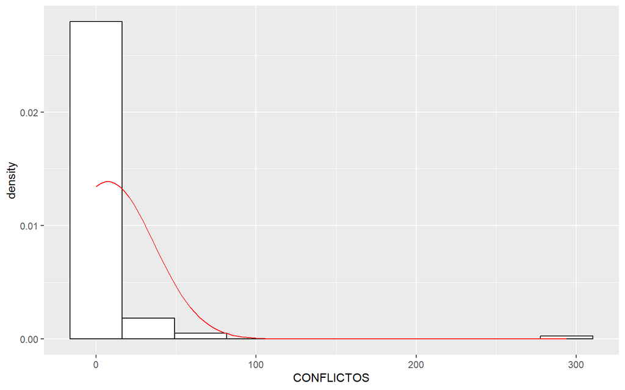

```r
library(ggplot2)
base=ggplot(data=protestas,
            aes(x=CONFLICTOS))
histogram= base + geom_histogram(aes(y = after_stat(density)),
                 colour = 1, fill = "white",bins=10) +
    stat_function(fun = dnorm,
                  args = list(mean = allStats['Mean'],
                              sd = allStats['sd']),col='red')

histogram
```

Podemos verlo en un boxplot:

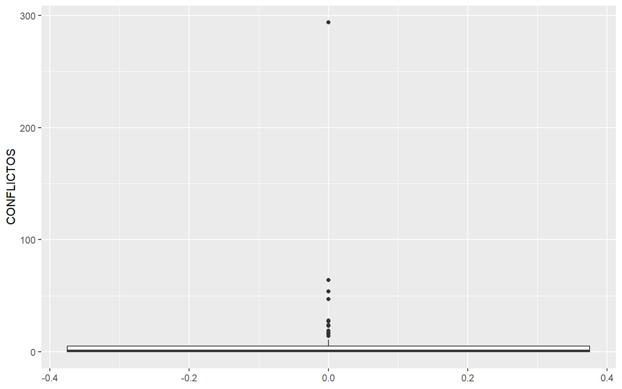

```r
base=ggplot(data=protestas,
            aes(y=CONFLICTOS))
boxplot=base + geom_boxplot()

boxplot
```

Podemos identificar a los atípicos:

```r
valuesFromBox=ggplot_build(boxplot)$data[[1]]
valuesFromBox
```

```
##   ymin lower middle upper ymax
## 1    0     0      1     5   11
##                                                      outliers notchupper
## 1 14, 16, 54, 28, 16, 19, 27, 294, 23, 17, 64, 47, 24, 16, 14   1.733497
##   notchlower x flipped_aes PANEL group ymin_final ymax_final   xmin  xmax xid
## 1  0.2665034 0       FALSE     1    -1          0        294 -0.375 0.375   1
##   newx new_width weight colour  fill alpha shape linetype linewidth
## 1    0      0.75      1 grey20 white    NA    19    solid       0.5
```

```r
outliersLocales=valuesFromBox$outliers[[1]]
outliersLocales
```

```
##  [1]  14  16  54  28  16  19  27 294  23  17  64  47  24  16  14
```

Podemos calcular los outliers usando los máximos y mínimos teóricos:

```r
valuesFromBox[c('ymin','ymax')]
```

```
##   ymin ymax
## 1    0   11
```

Entonces, los valores que excedan 11 serán considerados atípicos:

```r
protestas[protestas$CONFLICTOS>11,]
```

```
##          NOM_DIST      NOM_PROV UBIGEO CONFLICTOS PP_Nac_Loc PP_Nom POBLACION
## 9            ANTA          ANTA  80301         14          2   MRIP     26916
## 34      COMBAPATA       CANCHIS  80603         16          1     PL      4495
## 39        SICUANI       CANCHIS  80601         54          2   MRIP     65864
## 41     CAPACMARCA  CHUMBIVILCAS  80702         28          1     SP      4064
## 43    COLQUEMARCA  CHUMBIVILCAS  80704         16          1     PL      6923
## 47    SANTO TOMAS  CHUMBIVILCAS  80701         19          1    APP     22624
## 48        VELILLE  CHUMBIVILCAS  80708         27          1     PL      8587
## 50          CUSCO         CUSCO  80101        294          2   MRIP    119148
## 56        WANCHAQ         CUSCO  80108         23          1    PFE     61530
## 59      COPORAQUE       ESPINAR  80803         17          1     SP      8688
## 60        ESPINAR       ESPINAR  80801         64          2     AA     40781
## 77      SANTA ANA LA CONVENCION  80901         47          1    APP     29456
## 112   MACHUPICCHU      URUBAMBA  81304         24          1     SP      5761
## 114 OLLANTAYTAMBO      URUBAMBA  81306         16          1     SP     12061
```

[output cut: 33 more lines]

Podemos decir que las protestas se distribuyen por lo general entre 0 y 11 entre todos los distritos del Cusco. Asimismo, a través de la mediana, notamos que la mitad de los distritos tienen a lo más 1 conflicto. Por otro lado, los distritos destacados son 15; sin embargo, podemos apreciar como Cusco posee una distancia considerable con sus pares.

# Regresión Poisson

En nuestro caso, lo ideal resulta ser correr una regresión Poisson, ya que nuestra variable dependiente se trata de un conteo, el conteo de los conflictos a nivel distrital.

```r
library("modelsummary")
hipo = formula(CONFLICTOS ~ PP_Nac_Loc + PP_Nom + ALTITUD + TRANS_TOTAL_MILL + EJE_TOTAL_MILL + POR_EJE_RELA + RENTA_PER)

rp = glm(hipo, data = protestas,
         offset = log(POBLACION),   # variable de control: población
         family = poisson(link = "log"))

modelo = list('Poisson asegurado (I)' = rp)

modelsummary(modelo,
             title = "Regresión Poisson",
             stars = TRUE,
             output = "kableExtra")
```

Regresión Poisson

|  | &nbsp;Poisson asegurado (I) |
| --- | --- |
| (Intercept) | 9.591 |
|  | (469.324) |
| PP_Nac_Loc2 | -14.913 |
|  | (469.324) |
| PP_NomAPP | -15.443 |
|  | (469.324) |
| PP_NomFIA | 0.420 |
|  | (0.518) |
| PP_NomJP | -16.220 |
|  | (469.324) |
| PP_NomMIRP | -2.282** |
|  | (0.748) |
| PP_NomMRIP | -0.237 |
|  | (0.224) |
| PP_NomPFE | -16.663 |
|  | (469.324) |
| PP_NomPL | -14.705 |
|  | (469.324) |
| PP_NomPP | -15.518 |
|  | (469.324) |
| PP_NomSP | -15.684 |
|  | (469.324) |
| ALTITUD | 0.000 |
|  | (0.000) |
| TRANS_TOTAL_MILL | -0.168*** |
|  | (0.010) |
| EJE_TOTAL_MILL | 0.140*** |
|  | (0.009) |
| POR_EJE_RELA | -0.016*** |
|  | (0.004) |
| RENTA_PER | -0.001*** |
|  | (0.000) |
| Num.Obs. | 116 |
| AIC | 1182.9 |
| BIC | 1227.0 |
| Log.Lik. | -575.451 |
| F | 26.954 |
| RMSE | 13.12 |

+ p < 0.1, * p < 0.05, ** p < 0.01, *** p < 0.001

Lectura de la tabla, pero se necesita la exponenciación

```r
formatoNum <- function(x) format(x, digits = 4, scientific = FALSE)

modelsummary(modelo,
             fmt=formatoNum, # uso mi formula
             exponentiate = T, # exponenciar!!!!!
             statistic = 'conf.int',
             title = "Regresión Poisson - coeficientes exponenciados",
             stars = TRUE,
             output = "kableExtra")
```

Regresión Poisson - coeficientes exponenciados

|  | &nbsp;Poisson asegurado (I) |
| --- | --- |
| (Intercept) | 14629.83083565770 |
|  | [0.00000, Inf] |
| PP_Nac_Loc2 | 0.00000033359 |
|  | [0.00000, Inf] |
| PP_NomAPP | 0.00000019646 |
|  | [0.00000, Inf] |
| PP_NomFIA | 1.52231442599 |
|  | [0.55169, 4.2006] |
| PP_NomJP | 0.00000009033 |
|  | [0.00000, Inf] |
| PP_NomMIRP | 0.10205779607** |
|  | [0.02354, 0.4425] |
| PP_NomMRIP | 0.78925798041 |
|  | [0.50873, 1.2245] |
| PP_NomPFE | 0.00000005801 |
|  | [0.00000, Inf] |
| PP_NomPL | 0.00000041072 |
|  | [0.00000, Inf] |
| PP_NomPP | 0.00000018225 |
|  | [0.00000, Inf] |
| PP_NomSP | 0.00000015442 |
|  | [0.00000, Inf] |
| ALTITUD | 1.00009440471 |
|  | [0.99994, 1.0002] |
| TRANS_TOTAL_MILL | 0.84512193445*** |
|  | [0.82809, 0.8625] |
| EJE_TOTAL_MILL | 1.15024901923*** |
|  | [1.13086, 1.1700] |
| POR_EJE_RELA | 0.98437738017*** |
|  | [0.97751, 0.9913] |
| RENTA_PER | 0.99909997345*** |
|  | [0.99889, 0.9993] |
| Num.Obs. | 116 |
| AIC | 1182.9 |
| BIC | 1227.0 |
| Log.Lik. | -575.451 |
| F | 26.954 |
| RMSE | 13.12 |

+ p < 0.1, * p < 0.05, ** p < 0.01, *** p < 0.001

Interpretación

## Equidispersión

Uno de los supuestos de la regresión Poisson señala que tanto la media y la varianza deben ser iguales. Para conocer si nuestra regresión cumple esa condición probemos lo siguiente:

```r
library(magrittr)
library(kableExtra)
overdispersion=AER::dispersiontest(rp,alternative='greater')$ p.value<0.05
underdispersion=AER::dispersiontest(rp,alternative='less')$ p.value<0.05
# tabla
testResult=as.data.frame(rbind(overdispersion,underdispersion))
names(testResult)='Es probable?'
testResult%>%kable(caption = "Test de Equidispersión")%>%kableExtra::kable_styling()
```

Test de Equidispersión

|  | Es probable? |
| --- | --- |
| overdispersion | FALSE |
| underdispersion | FALSE |

Interpretación:

### Quasi Poisson

Útil para la sobredispersión y subdispersión.

```r
rqp = glm(hipo, data = protestas,
          offset = log(POBLACION),
          family = quasipoisson(link="log"))

modelsummary(rqp,
             title = "Regresión QuasiPoisson",
             stars = TRUE,
             output = "kableExtra")
```

Regresión QuasiPoisson

|  | &nbsp;(1) |
| --- | --- |
| (Intercept) | 9.591 |
|  | (2952.363) |
| PP_Nac_Loc2 | -14.913 |
|  | (2952.363) |
| PP_NomAPP | -15.443 |
|  | (2952.363) |
| PP_NomFIA | 0.420 |
|  | (3.258) |
| PP_NomJP | -16.220 |
|  | (2952.363) |
| PP_NomMIRP | -2.282 |
|  | (4.708) |
| PP_NomMRIP | -0.237 |
|  | (1.410) |
| PP_NomPFE | -16.663 |
|  | (2952.363) |
| PP_NomPL | -14.705 |
|  | (2952.363) |
| PP_NomPP | -15.518 |
|  | (2952.363) |
| PP_NomSP | -15.684 |
|  | (2952.363) |
| ALTITUD | 0.000 |
|  | (0.000) |
| TRANS_TOTAL_MILL | -0.168* |
|  | (0.065) |
| EJE_TOTAL_MILL | 0.140* |
|  | (0.055) |
| POR_EJE_RELA | -0.016 |
|  | (0.022) |
| RENTA_PER | -0.001 |
|  | (0.001) |
| Num.Obs. | 116 |
| F | 0.681 |
| RMSE | 13.12 |

+ p < 0.1, * p < 0.05, ** p < 0.01, *** p < 0.001

### Binomial Negativa

Útil solo para la sobredispersión

```r
library(MASS)

hipo_bn = formula(CONFLICTOS ~ PP_Nac_Loc + PP_Nom + ALTITUD + TRANS_TOTAL_MILL + EJE_TOTAL_MILL + POR_EJE_RELA + RENTA_PER + offset(log(POBLACION)))

rbn = glm.nb(hipo_bn, data = protestas)
modelsummary(rbn,
             title = "Regresión BinomialNegativa",
             stars = TRUE,
             output = "kableExtra")
```

Regresión BinomialNegativa

|  | &nbsp;(1) |
| --- | --- |
| (Intercept) | 25.498 |
|  | (54193412.522) |
| PP_Nac_Loc2 | -30.641 |
|  | (54193412.522) |
| PP_NomAPP | -30.195 |
|  | (54193412.522) |
| PP_NomFIA | -0.133 |
|  | (1.416) |
| PP_NomJP | -30.959 |
|  | (54193412.522) |
| PP_NomMIRP | -1.067 |
|  | (1.575) |
| PP_NomMRIP | 0.222 |
|  | (1.148) |
| PP_NomPFE | -31.344 |
|  | (54193412.522) |
| PP_NomPL | -29.447 |
|  | (54193412.522) |
| PP_NomPP | -29.905 |
|  | (54193412.522) |
| PP_NomSP | -30.322 |
|  | (54193412.522) |
| ALTITUD | 0.000 |
|  | (0.000) |
| TRANS_TOTAL_MILL | -0.086* |
|  | (0.034) |
| EJE_TOTAL_MILL | 0.073** |
|  | (0.028) |
| POR_EJE_RELA | -0.026* |
|  | (0.011) |
| RENTA_PER | 0.000+ |
|  | (0.000) |
| Num.Obs. | 116 |
| AIC | 547.5 |
| BIC | 594.3 |
| Log.Lik. | -256.733 |
| RMSE | 23.29 |

+ p < 0.1, * p < 0.05, ** p < 0.01, *** p < 0.001

## Vemos nuestras regresiones

```r
todos_modelos = list('Poisson'= rp,
                     'Quasi Poisson'= rqp,
                     'Binomial Negativa'= rbn)

modelsummary(todos_modelos, fmt=formatoNum,
             exponentiate = T,
             statistic = 'conf.int',
             title = "EXP de las Regresiones",
             stars = TRUE,
             output = "kableExtra")
```

EXP de las Regresiones

|  | Poisson | Quasi Poisson | Binomial Negativa |
| --- | --- | --- | --- |
| (Intercept) | 14629.83083565770 | 14629.83083565770 | 118457256029.21917724609375000 |
|  | [0.00000, Inf] | [0.000000000, Inf] | [0.00000, Inf] |
| PP_Nac_Loc2 | 0.00000033359 | 0.00000033359 | 0.00000000000004930 |
|  | [0.00000, Inf] | [0.000000000, Inf] | [0.00000, Inf] |
| PP_NomAPP | 0.00000019646 | 0.00000019646 | 0.00000000000007703 |
|  | [0.00000, Inf] | [0.000000000, Inf] | [0.00000, Inf] |
| PP_NomFIA | 1.52231442599 | 1.52231442599 | 0.87523914643774681 |
|  | [0.55169, 4.2006] | [0.002374312, 976.0475] | [0.05459, 14.0334] |
| PP_NomJP | 0.00000009033 | 0.00000009033 | 0.00000000000003585 |
|  | [0.00000, Inf] | [0.000000000, Inf] | [0.00000, Inf] |
| PP_NomMIRP | 0.10205779607** | 0.10205779607 | 0.34411085073951819 |
|  | [0.02354, 0.4425] | [0.000008962, 1162.2330] | [0.01569, 7.5448] |
| PP_NomMRIP | 0.78925798041 | 0.78925798041 | 1.24899388785346055 |
|  | [0.50873, 1.2245] | [0.048162199, 12.9340] | [0.13166, 11.8489] |
| PP_NomPFE | 0.00000005801 | 0.00000005801 | 0.00000000000002440 |
|  | [0.00000, Inf] | [0.000000000, Inf] | [0.00000, Inf] |
| PP_NomPL | 0.00000041072 | 0.00000041072 | 0.00000000000016261 |
|  | [0.00000, Inf] | [0.000000000, Inf] | [0.00000, Inf] |
| PP_NomPP | 0.00000018225 | 0.00000018225 | 0.00000000000010292 |
|  | [0.00000, Inf] | [0.000000000, Inf] | [0.00000, Inf] |
| PP_NomSP | 0.00000015442 | 0.00000015442 | 0.00000000000006779 |
|  | [0.00000, Inf] | [0.000000000, Inf] | [0.00000, Inf] |
| ALTITUD | 1.00009440471 | 1.00009440471 | 0.99976817818028973 |
|  | [0.99994, 1.0002] | [0.999121608, 1.0011] | [0.99938, 1.0002] |
| TRANS_TOTAL_MILL | 0.84512193445*** | 0.84512193445* | 0.91767510654856532* |
|  | [0.82809, 0.8625] | [0.742349047, 0.9621] | [0.85817, 0.9813] |
| EJE_TOTAL_MILL | 1.15024901923*** | 1.15024901923* | 1.07557784557850367** |
|  | [1.13086, 1.1700] | [1.032259876, 1.2817] | [1.01891, 1.1354] |
| POR_EJE_RELA | 0.98437738017*** | 0.98437738017 | 0.97468967397288020* |
|  | [0.97751, 0.9913] | [0.941472417, 1.0292] | [0.95303, 0.9968] |
| RENTA_PER | 0.99909997345*** | 0.99909997345 | 0.99963309005571299+ |
|  | [0.99889, 0.9993] | [0.997793585, 1.0004] | [0.99926, 1.0000] |
| Num.Obs. | 116 | 116 | 116 |
| AIC | 1182.9 |  | 547.5 |
| BIC | 1227.0 |  | 594.3 |
| Log.Lik. | -575.451 |  | -256.733 |
| F | 26.954 | 0.681 |  |
| RMSE | 13.12 | 13.12 | 23.29 |

+ p < 0.1, * p < 0.05, ** p < 0.01, *** p < 0.001

# Comparando modelos

```r
# poisson case
performance::check_overdispersion(rp)
```

```
## # Overdispersion test
##
##        dispersion ratio =   39.573
##   Pearson's Chi-Squared = 3957.260
##                 p-value =  < 0.001
```

```
## Overdispersion detected.
```

```r
# quasipoisson case
performance::check_overdispersion(rqp)
```

```
## # Overdispersion test
##
##        dispersion ratio =   39.573
##   Pearson's Chi-Squared = 3957.260
##                 p-value =  < 0.001
```

```
## Overdispersion detected.
```

```r
# negative binomial case
performance::check_overdispersion(rbn)
```

```
## # Overdispersion test
##
##  dispersion ratio = 2.247
##           p-value = 0.168
```

```
## No overdispersion detected.
```

Como no son modelos anidados, usamos la tabla anova con cuidado, pidiendo un test chi-cuadrado:

```r
anova(rp,rqp,rbn,test = "Chisq") %>%
kable(caption = "Tabla ANOVA para comparar modelos")%>%kableExtra::kable_styling(full_width = FALSE)
```

Tabla ANOVA para comparar modelos

| Resid. Df | Resid. Dev | Df | Deviance | Pr(>Chi) |
| --- | --- | --- | --- | --- |
| 100 | 923.9822 | NA | NA | NA |
| 100 | 923.9822 | 0 | 0.0000 | NA |
| 100 | 114.8470 | 0 | 809.1352 | NA |

Aquí nos fijamos en el Resid.Dev, si decae de una regresión a otra suele ser mejor la última opción.

Podemos emplear otra prueba:

```r
lmtest::lrtest(rp,rbn)%>%
kable(caption = "loglikelihood ratio test")%>%kableExtra::kable_styling(full_width = FALSE)
```

loglikelihood ratio test

| #Df | LogLik | Df | Chisq | Pr(>Chisq) |
| --- | --- | --- | --- | --- |
| 16 | -575.4507 | NA | NA | NA |
| 17 | -256.7333 | 1 | 637.4349 | 0 |

Aquí nos fijamos en el LogLik, si el número se acerca más al 0 de una regresión a otra, suele ser mejor.